# Część II - konstrukcja modelu

## Wstęp

W niniejszej części sprawozdania skupimy się na budowie modeli predykcyjnych z wykorzystaniem algorytmu XGBoost.  
Zostanie opracowanych kilka wariantów modeli, które następnie porównamy pod kątem ich skuteczności predykcyjnej.  
Dodatkowo przeanalizujemy wpływ poszczególnych zmiennych na decyzje modelu, co umożliwi lepsze zrozumienie czynników mających kluczowe znaczenie w procesie predykcji.  
Ostatecznym celem jest wybór najlepszego modelu spośród analizowanych konfiguracji.

```python
import pandas as pd
from IPython.display import display
import warnings
import xgboost as xgb
from sklearn.preprocessing import LabelEncoder
from sklearn.model_selection import train_test_split
from sklearn.metrics import roc_auc_score, confusion_matrix, ConfusionMatrixDisplay, roc_curve, auc,f1_score
import matplotlib.pyplot as plt
from sklearn.inspection import permutation_importance
import shap
from skopt.space import Integer, Real
from skopt import BayesSearchCV
import warnings
warnings.filterwarnings("ignore")
pd.set_option('display.max_colwidth', None)
warnings.filterwarnings("ignore", category=UserWarning, module='tqdm')
```

```python
dane=pd.read_csv("C:/Users/Eweli/Bankowość/dane_list2.csv",sep=';')
dane=dane.reset_index()
dane=dane.rename(columns={'index':'customer_id'})
warnings.filterwarnings("ignore", category=FutureWarning)
dane["y"] = dane["y"].replace("yes", 1)
dane["y"] = dane["y"].replace("no", 0)
encoder_dict = {}
dane2 = dane.copy()
encoder = LabelEncoder()

for col in dane2.select_dtypes(include='object').columns:
    dane2[col] = encoder.fit_transform(dane2[col])
    encoder_dict[col] = {i: label for i, label in enumerate(encoder.classes_)}

X_train, X_test, y_train, y_test = train_test_split(dane2[[i for i in dane2.columns if i not in ['y','customer_id']]],
                                               dane2.y,
                                               test_size=0.2,
                                               random_state=20)
```

```python
def gini(true_val, predicted_val):
    return 2 * roc_auc_score(true_val, predicted_val) - 1


def rysuj_wykres_miary(wartosci_fi, tytul, nazwa_osi, ax=None, col='royalblue', kolumny=X_train, top_only=False):
    if ax is None:
        fig, ax = plt.subplots(figsize=(8, 6))

    df_to_plot = pd.DataFrame({
        'nazwy': kolumny.columns,
        'wielkosc_miary': wartosci_fi
    })
    df_to_plot = df_to_plot.sort_values(by='wielkosc_miary', ascending=False)

    if top_only:
        df_to_plot = df_to_plot.head(20)

    df_to_plot = df_to_plot.sort_values(by='wielkosc_miary', ascending=True)

    ax.barh(df_to_plot['nazwy'], df_to_plot['wielkosc_miary'],
            color=col, edgecolor='black', align='center', alpha=0.8)

    ax.set_title(tytul)
    ax.set_xlabel(nazwa_osi)
    ax.grid(axis='x', linestyle='--', alpha=0.7)

    if top_only:
        ax.tick_params(labelsize=9)




def model_summary(model, model_name, description, X_train, X_test, y_train, y_test):

    y_train_pred = model.predict_proba(X_train)[:, 1]
    y_test_pred = model.predict_proba(X_test)[:, 1]


    gini_train = gini(y_train, y_train_pred)
    gini_test = gini(y_test, y_test_pred)

    num_features = X_train.shape[1]

    return pd.DataFrame({
        "Nazwa modelu": [model_name],
        "Opis": [description],
        "Liczba zmiennych": [num_features],
        "Gini TRAIN": [round(gini_train * 100, 4)],
        "Gini TEST": [round(gini_test * 100, 4)]
    })

def rysuj_roc(model, X_train, y_train, X_test, y_test, model_name="Model"):
    plt.figure(figsize=(12, 5))

    plt.subplot(1, 2, 1)
    y_train_proba = model.predict_proba(X_train)[:, 1]
    fpr_train, tpr_train, _ = roc_curve(y_train, y_train_proba)
    auc_train = roc_auc_score(y_train, y_train_proba)
    plt.plot(fpr_train, tpr_train, color='darkblue', label=f"AUC = {auc_train:.4f}")
    plt.plot([0, 1], [0, 1], linestyle='--', color='gray')
    plt.title(f"{model_name} - ROC (TRAIN)")
    plt.xlabel("False Positive Rate")
    plt.ylabel("True Positive Rate")
    plt.grid(alpha=0.3)
    plt.legend()

    plt.subplot(1, 2, 2)
    y_test_proba = model.predict_proba(X_test)[:, 1]
    fpr_test, tpr_test, _ = roc_curve(y_test, y_test_proba)
    auc_test = roc_auc_score(y_test, y_test_proba)
    plt.plot(fpr_test, tpr_test, color='darkgreen', label=f"AUC = {auc_test:.4f}")
    plt.plot([0, 1], [0, 1], linestyle='--', color='gray')
    plt.title(f"{model_name} - ROC (TEST)")
    plt.xlabel("False Positive Rate")
    plt.ylabel("True Positive Rate")
    plt.grid(alpha=0.3)
    plt.legend()

    plt.tight_layout()
    plt.show()
```

## W jaki sposób będziemy oceniać budowane modele?

Ocena jakości budowanych modeli zostanie przeprowadzona w dwóch głównych obszarach: skuteczności predykcji oraz znaczenia zmiennych wejściowych.  
W ramach tej analizy zastosowane zostaną następujące metody:

**Ocena jakości predykcji**:

- **Miara GINI**

Miara Gini stanowi transformację wartości AUC, czyli pola pod krzywą ROC. Wyraża się wzorem: $$\text{GINI = } 2\cdot\text{AUC} - 1$$

Jest powszechnie stosowana do oceny zdolności modelu do rozróżniania klas w problemach klasyfikacji binarnej. Przyjmuje wartości z przedziału [-1,1], gdzie wartość 0 oznacza model losowy, a 1 – model idealnie klasyfikujący.  
*Im wyższa wartość Gini, tym większa skuteczność predykcji.*

- **Krzywa ROC**

Krzywa ROC pokazuje, jak dobrze model rozróżnia między dwiema klasami (np. sukces vs. brak sukcesu).  
Przedstawia zależność pomiędzy:  
Czułością (na osi Y) - proporcja prawdziwie pozytywnych wyników (TPR) : $TPR = \frac{TP}{TP+FN}$

Swoistością (na osi X) - proporcja fałszywie pozytywnych wyników (FPR): $FPR = \frac{FP}{FP+TN}$

*Interpretacja*:

- Im bliżej lewego górnego rogu (czyli im wyższa krzywa), tym lepszy model.
- Pole pod krzywą (AUC) – im bliżej 1, tym lepiej model klasyfikuje przypadki.
- Linia przerywana (kąt 45°) oznacza losowe zgadywanie – model poniżej tej linii jest gorszy niż losowa klasyfikacja.

**Ocena jakości zmiennych**:

- **Miara GAIN**

Miara GAIN opiera się na analizie struktury drzew wchodzących w skład modelu XGBoost.  
Określa, jak bardzo dana zmienna przyczynia się do redukcji funkcji straty w momencie, gdy wykorzystywana jest do podziału węzła w drzewie.

Dla każdego rozgałęzienia w drzewie wybór cechy decyzyjnej dokonywany jest tak, aby maksymalizować przyrost informacji.  
Miara GAIN to suma redukcji błędu dla danej zmiennej we wszystkich miejscach drzewa, w których była użyta, uśredniona w odniesieniu do liczby takich wystąpień.  
W kontekście XGBoost, dla funkcji straty $ L $, GAIN dla cechy $x_j$ może być zapisany jako:

$$ \text{GAIN}(x_j) = \sum_{i \in \text{split}(x_j)} \left[ L_{\text{before split}} - L_{\text{after split}} \right] $$

*Im wyższa wartość GAIN, tym większy wkład zmiennej w proces decyzyjny.*

- **Permutation Importance**

Permutation Importance to modelowo niezależna metoda oceny ważności zmiennych, która pozwala uwzględnić zależności między zmiennymi oraz ich wpływ na jakość predykcji.

Główna idea polega na tym, że jeśli losowo permutujemy (mieszamy) wartości jednej zmiennej i ponownie ocenimy model na zbiorze testowym, to ewentualny spadek jakości predykcji wskaże, jak bardzo ta cecha była istotna.

Formalnie:

$$ \text{Importance}(x_j) = \text{Score}_{\text{original}} - \text{Score}_{\text{permuted } x_j} $$

gdzie:

- $ \text{Score}_{\text{original}} $ – skuteczność modelu na niezmienionym zbiorze,
- $ \text{Score}_{\text{permuted } x_j} $ – skuteczność po permutacji cechy $ x_j $.

*Zmienna, dla której różnica ta jest największa, uznawana jest za najważniejszą.*

- **SHAP (SHapley Additive exPlanations)**

SHAP to zaawansowana metoda wyjaśniania decyzji modelu, oparta na teorii wartości Shapleya z teorii gier koalicyjnych. Umożliwia ona przypisanie każdej zmiennej wkładu do konkretnej predykcji modelu.

Dla obserwacji $ i $, predykcję modelu $ f(x^{(i)}) $ można przedstawić jako sumę wpływów poszczególnych cech:

$$ f(x^{(i)}) = \phi_0 + \sum_{j=1}^{M} \phi_j^{(i)} $$

gdzie:

- $ \phi_0 $ to wartość bazowa (średnia predykcja),
- $ \phi_j^{(i)} $ to wartość SHAP dla zmiennej $ j $ w obserwacji $ i $,
- $ M $ to liczba zmiennych.

SHAP jako jedyna metoda spełnia wszystkie trzy pożądane właściwości interpretowalności: **lokalność**, **spójność** i **addytywność**. Dzięki temu pozwala zarówno na analizę globalną (ważność cech w całym zbiorze), jak i lokalną (dlaczego dana obserwacja została zaklasyfikowana w określony sposób).

W niniejszej analizie wykorzystamy wykresy SHAP dla finalnego modelu, by uzyskać pełniejszy wgląd w mechanizmy decyzyjne algorytmu oraz zwiększyć jego przejrzystość.

## Model 1 - skonstruowany na domyślnych hiperparametrach

```python
model1 = xgb.XGBClassifier()
model1.fit(X_train, y_train);
```

```python
model_results = pd.DataFrame()
summary1 = model_summary(model1, "Model 1", "model na domyślnych hiperparametrach", X_train, X_test, y_train, y_test)
model_results = pd.concat([model_results, summary1], ignore_index=True)
model_results.style.format(lambda x: f"{x:.3f}" if isinstance(x, float) else x) \
        .set_table_styles([
        {'selector': 'td, th', 'props': [('border', '1px solid black')]},
        {'selector': 'tr:nth-child(even)', 'props': [('background-color', 'lightgray')]},
        {'selector': 'tr:nth-child(odd)', 'props': [('background-color', 'white')]},
        {'selector': 'caption', 'props': [('font-weight', 'bold')]},
    ]) \
    .hide(axis="index").set_table_attributes("style='margin:auto; font-size:16px'").set_caption("Podsumowanie modelu")
```

Podsumowanie modelu

| Nazwa modelu | Opis | Liczba zmiennych | Gini TRAIN | Gini TEST |
| --- | --- | --- | --- | --- |
| Model 1 | model na domyślnych hiperparametrach | 16 | 96.024 | 86.911 |

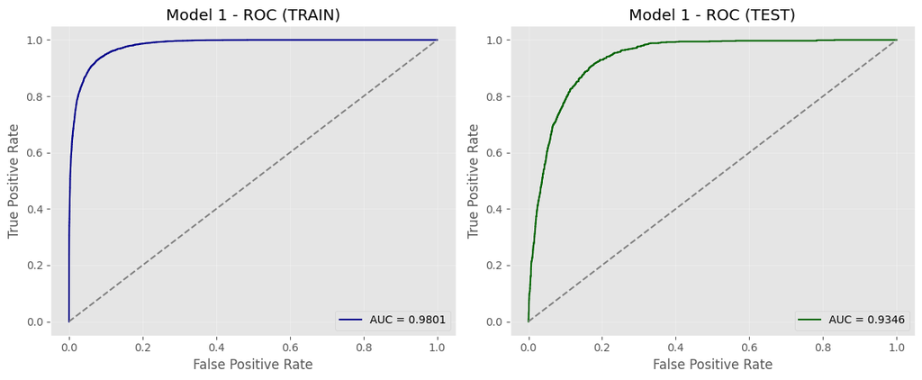

```python
plt.style.use('ggplot')
rysuj_roc(model1, X_train, y_train, X_test, y_test, model_name="Model 1")
```

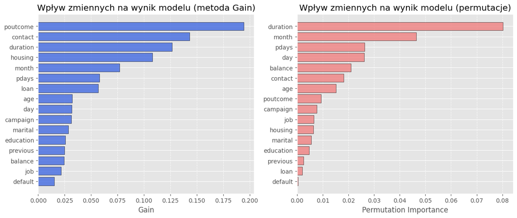

```python
plt.style.use('ggplot')
pi_results = permutation_importance(model1, X_train,y_train,n_repeats=10,random_state=0)
fig, axes = plt.subplots(1, 2, figsize=(12, 5), frameon=True, constrained_layout=True)
rysuj_wykres_miary(model1.feature_importances_,"Wpływ zmiennych na wynik modelu (metoda Gain)","Gain",ax=axes[0])
rysuj_wykres_miary(pi_results.importances_mean,"Wpływ zmiennych na wynik modelu (permutacje)","Permutation Importance",ax=axes[1],col='lightcoral')
plt.show()
```

## Model 2 - z optymalizacją hiperparametrów

Drugi model XGBoost zostanie zbudowany z wykorzystaniem procedury automatycznej optymalizacji hiperparametrów.  
Celem tego etapu jest znalezienie takich wartości parametrów, które maksymalizują jakość predykcji modelu, mierzoną przy pomocy negatywnego błędu średniokwadratowego.

**Zakres przestrzeni parametrów**

Do optymalizacji wykorzystujemy podejście bayesowskie (`BayesSearchCV` z biblioteki `skopt`), które w sposób efektywny przeszukuje przestrzeń parametrów, budując iteracyjnie probabilistyczny model funkcji celu.

```python
model2 = xgb.XGBClassifier();
```

```python
param_space = {
    'n_estimators': Integer(50,200), # liczba drzew w modelu
    'max_depth': Integer(3,10), # maksymalna głębokość drzewa
    'min_child_weight':Integer(1,200), # minimalna suma wag w węźle potomnym
    'learning_rate': Real(0.01,0.3,prior='log-uniform'), # współczynnik uczenia
    'subsample': Real(0.6,1.0),  # udział próbki danych dla pojedynczego drzewa
    'colsample_bytree': Real(0.6,1.0), # udział cech dla pojedynczego drzewa
    'gamma': Real(1e-4,10,prior='log-uniform'), # minimalna wartość funkcji kosztu, aby wykonać podział
    'reg_lambda': Real(1e-4,10,prior='log-uniform'), # współczynnik regularyzacji L2
    'reg_alpha': Real(1e-4,10,prior='log-uniform'),  # współczynnik regularyzacji L1
}
```

```python
grid_search1 = BayesSearchCV(
    estimator = model2,
    search_spaces = param_space,
    scoring = 'neg_mean_squared_error',
    n_iter = 50,
    cv=3,
    verbose=3,
    random_state=42
)
```

```python
import sys
import os
import contextlib

with contextlib.redirect_stdout(open(os.devnull, 'w')):
    grid_search1.fit(X_train, y_train)
```

```python
summary2 = model_summary(grid_search1, "Model 2", "model ze zoptymalizowanymi hiperparametrami", X_train, X_test, y_train, y_test)
model_results = pd.concat([model_results, summary2], ignore_index=True)
model_results.style.format(lambda x: f"{x:.3f}" if isinstance(x, float) else x) \
        .set_table_styles([
        {'selector': 'td, th', 'props': [('border', '1px solid black')]},
        {'selector': 'tr:nth-child(even)', 'props': [('background-color', 'lightgray')]},
        {'selector': 'tr:nth-child(odd)', 'props': [('background-color', 'white')]},
        {'selector': 'caption', 'props': [('font-weight', 'bold')]},
    ]) \
    .hide(axis="index").set_table_attributes("style='margin:auto; font-size:16px'").set_caption("Podsumowanie modeli")
```

Podsumowanie modeli

| Nazwa modelu | Opis | Liczba zmiennych | Gini TRAIN | Gini TEST |
| --- | --- | --- | --- | --- |
| Model 1 | model na domyślnych hiperparametrach | 16 | 96.024 | 86.911 |
| Model 2 | model ze zoptymalizowanymi hiperparametrami | 16 | 92.149 | 87.338 |

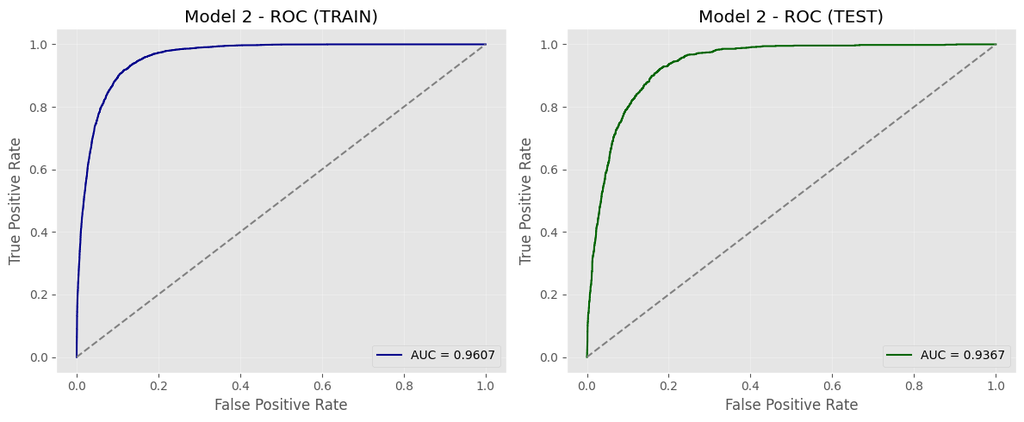

```python
rysuj_roc(grid_search1, X_train, y_train, X_test, y_test, model_name="Model 2")
```

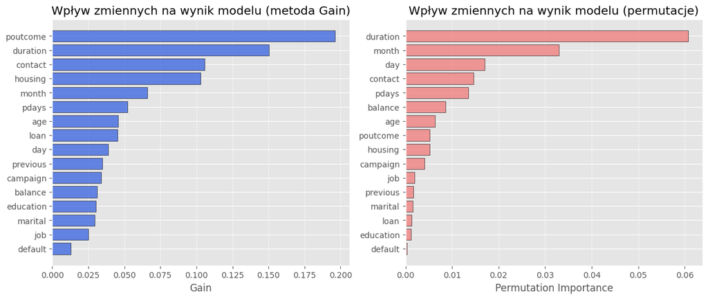

```python
pi_results = permutation_importance(grid_search1, X_train,y_train,n_repeats=10,random_state=0)
fig, axes = plt.subplots(1, 2, figsize=(12, 5), frameon=True, constrained_layout=True)
rysuj_wykres_miary(grid_search1.best_estimator_.feature_importances_
,"Wpływ zmiennych na wynik modelu (metoda Gain)","Gain",ax=axes[0])
rysuj_wykres_miary(pi_results.importances_mean,"Wpływ zmiennych na wynik modelu (permutacje)","Permutation Importance",ax=axes[1],col='lightcoral')
plt.show()
```

## Model 3 - skonstruowany na domyślnych hiperparametrach, z wykorzystaniem zmiennych typu 'dummy'

Trzeci model zostanie zbudowany przy użyciu zmiennych typu *dummy*.  
Są to zmienne binarne (0/1), powstałe w wyniku zakodowania zmiennych kategorycznych.  
Każda oryginalna zmienna kategoryczna zostaje przekształcona w zestaw nowych zmiennych binarnych, z których każda reprezentuje jedną z możliwych kategorii.

- Ze względu na znaczne zwiększenie liczby zmiennych w modelu, na wykresach GAIN i Permutation Importance przedstawimy wyłącznie 20 najbardziej wpływowych cech.

```python
dane3 = pd.get_dummies(dane[[i for i in dane.columns if i != 'y']])
```

```python
dane3 = dane3.drop(columns=['job_admin.','marital_divorced','education_primary','default_no','housing_no','loan_no',
                            'contact_cellular','month_apr','poutcome_failure','customer_id'])
```

```python
X_train_d = dane3.iloc[X_train.index, :].copy()
X_test_d = dane3.iloc[X_test.index, :].copy()
```

```python
model3 = xgb.XGBClassifier()
model3.fit(X_train_d,y_train);
```

```python
summary3 = model_summary(model3, "Model 3", "model na domyślnych parametrach ze zmiennymi dummy", X_train_d, X_test_d, y_train, y_test)
model_results = pd.concat([model_results, summary3], ignore_index=True)
model_results.style.format(lambda x: f"{x:.3f}" if isinstance(x, float) else x) \
        .set_table_styles([
        {'selector': 'td, th', 'props': [('border', '1px solid black')]},
        {'selector': 'tr:nth-child(even)', 'props': [('background-color', 'lightgray')]},
        {'selector': 'tr:nth-child(odd)', 'props': [('background-color', 'white')]},
        {'selector': 'caption', 'props': [('font-weight', 'bold')]},
    ]) \
    .hide(axis="index").set_table_attributes("style='margin:auto; font-size:16px'").set_caption("Podsumowanie modeli")
```

Podsumowanie modeli

| Nazwa modelu | Opis | Liczba zmiennych | Gini TRAIN | Gini TEST |
| --- | --- | --- | --- | --- |
| Model 1 | model na domyślnych hiperparametrach | 16 | 96.024 | 86.911 |
| Model 2 | model ze zoptymalizowanymi hiperparametrami | 16 | 92.149 | 87.338 |
| Model 3 | model na domyślnych parametrach ze zmiennymi dummy | 42 | 95.659 | 87.722 |

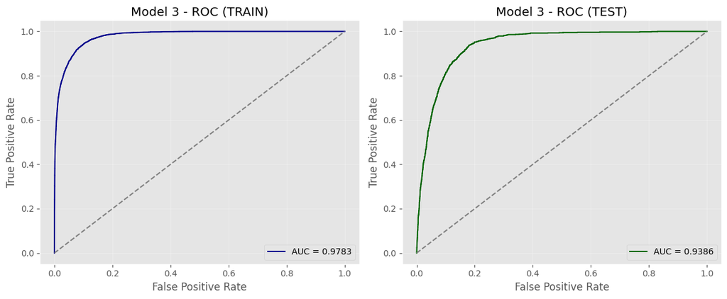

```python
rysuj_roc(model3, X_train_d, y_train, X_test_d, y_test, model_name="Model 3")
```

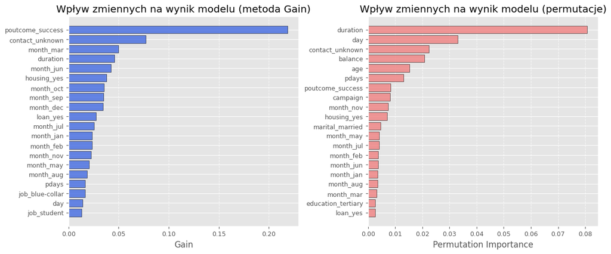

```python
pi_results = permutation_importance(model3, X_train_d,y_train,n_repeats=10,random_state=0)
fig, axes = plt.subplots(1, 2, figsize=(12, 5), frameon=True, constrained_layout=True)
rysuj_wykres_miary(model3.feature_importances_,"Wpływ zmiennych na wynik modelu (metoda Gain)","Gain",ax=axes[0],kolumny=X_train_d,top_only=True)
rysuj_wykres_miary(pi_results.importances_mean,"Wpływ zmiennych na wynik modelu (permutacje)","Permutation Importance",ax=axes[1],col='lightcoral',kolumny=X_train_d,top_only=True)
plt.show()
```

## Model 4 - skonstruowany z wykorzystaniem zmiennych typu 'dummy' i optymalizacja hiperametrów

```python
model4 = xgb.XGBClassifier()
grid_search2 = BayesSearchCV(
    estimator = model4,
    search_spaces = param_space,
    scoring = 'neg_mean_squared_error',
    n_iter = 50,
    cv=3,
    verbose=3,
    random_state=0
);
```

```python
import sys
import os
import contextlib

with contextlib.redirect_stdout(open(os.devnull, 'w')):
   grid_search2.fit(X_train_d,y_train)
```

```python
summary4 = model_summary(grid_search2, "Model 4", "model ze zoptymalizowanymi hiperparametrami ze zmiennymi dummy", X_train_d, X_test_d, y_train, y_test)
model_results = pd.concat([model_results, summary4], ignore_index=True)
model_results.style.format(lambda x: f"{x:.3f}" if isinstance(x, float) else x) \
        .set_table_styles([
        {'selector': 'td, th', 'props': [('border', '1px solid black')]},
        {'selector': 'tr:nth-child(even)', 'props': [('background-color', 'lightgray')]},
        {'selector': 'tr:nth-child(odd)', 'props': [('background-color', 'white')]},
        {'selector': 'caption', 'props': [('font-weight', 'bold')]},
    ]) \
    .hide(axis="index").set_table_attributes("style='margin:auto; font-size:16px'").set_caption("Podsumowanie modeli")
```

Podsumowanie modeli

| Nazwa modelu | Opis | Liczba zmiennych | Gini TRAIN | Gini TEST |
| --- | --- | --- | --- | --- |
| Model 1 | model na domyślnych hiperparametrach | 16 | 96.024 | 86.911 |
| Model 2 | model ze zoptymalizowanymi hiperparametrami | 16 | 92.149 | 87.338 |
| Model 3 | model na domyślnych parametrach ze zmiennymi dummy | 42 | 95.659 | 87.722 |
| Model 4 | model ze zoptymalizowanymi hiperparametrami ze zmiennymi dummy | 42 | 90.299 | 88.224 |

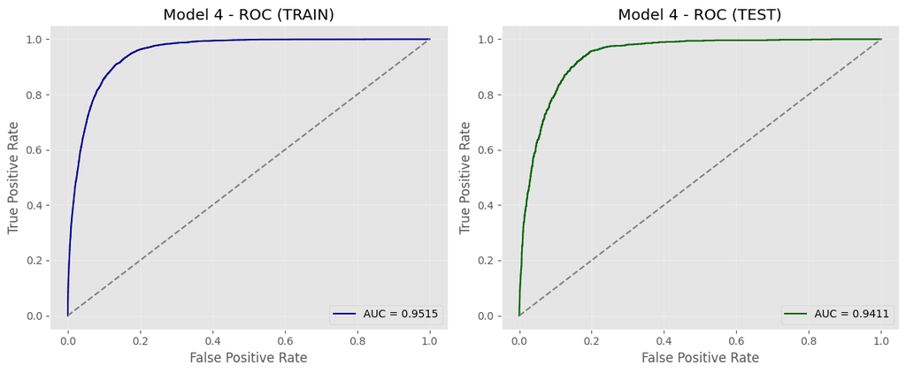

```python
rysuj_roc(grid_search2, X_train_d, y_train, X_test_d, y_test, model_name="Model 4")
```

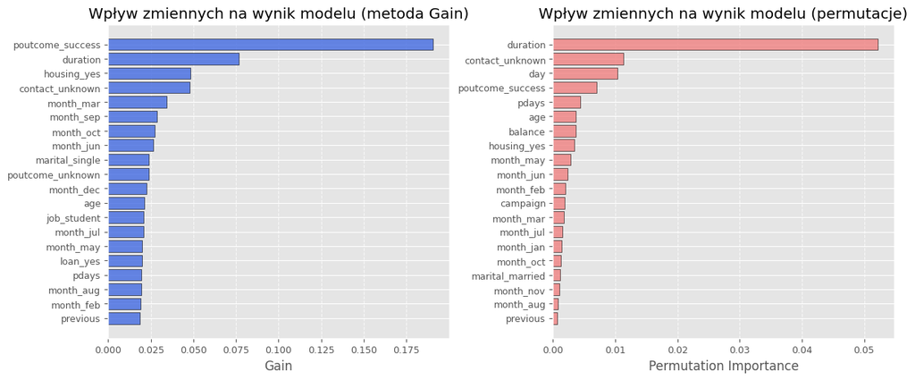

```python
pi_results = permutation_importance(grid_search2, X_train_d,y_train,n_repeats=10,random_state=0)
fig, axes = plt.subplots(1, 2, figsize=(12, 5), frameon=True, constrained_layout=True)
rysuj_wykres_miary(grid_search2.best_estimator_.feature_importances_,"Wpływ zmiennych na wynik modelu (metoda Gain)","Gain",ax=axes[0],kolumny=X_train_d,top_only=True)
rysuj_wykres_miary(pi_results.importances_mean,"Wpływ zmiennych na wynik modelu (permutacje)","Permutation Importance",ax=axes[1],kolumny=X_train_d,col='lightcoral',top_only=True)
plt.show()
```

## Obserwacje i wnioski

Wszystkie modele osiągają bardzo dobre wyniki, jednak różnią się pod względem dopasowania do danych treningowych i testowych.

- **GINI**

**Model 1 (bazowy)**: osiągnął najwyższy GINI na zbiorze treningowym (96.02), ale jednocześnie najniższy na zbiorze testowym (86.91), co sugeruje przeuczenie.

**Model 2**: GINI na zbiorze treningowym spadł do 92.15, natomiast wynik na teście nieznacznie wzrósł do 87.34, co wskazuje na lepsze uogólnianie niż w modelu 1.

**Model 3**: zachował bardzo wysoki GINI na treningu (95.66) i uzyskał lepszy wynik testowy (87.72), co pokazuje korzyści z rozbicia zmiennych kategorycznych.

**Model 4**: osiągnął najlepszy GINI na zbiorze testowym – 88.22, przy najniższym GINI na treningu (90.30), co świadczy o największej stabilności i odporności na przeuczenie.

- **Krzywa ROC**

Model 4 wykazuje najwyższe pole pod krzywą ROC, co przekłada się na najlepszy wskaźnik GINI.  
Krzywa ROC tego modelu znajduje się najbliżej lewego górnego rogu wykresu, co świadczy o jego wysokiej zdolności do rozróżniania klas.

- **Najważniejsze zmienne według GAIN**

`poutcome` – osiąga największą wartość predykcyjna w każdym modelu. W modelach z dummy najbardziej wpływową zmienną jest kateogria `poutcome_success`.

`duration` – w każdym modelu znajduje się wśród najważniejszych cech.

`contact` – konsekwentnie wysoko niezależnie od wersji modelu. Przy czym, dla dwóch ostatnich (ze zmiennymi dummy) wśród najważniejszych cech znajduje się kategoria `contact_unknown`.

`month` – także często w TOP 5, podobnie jak `housing` . Przy czym, dla modeli z dummy największy wpływ ma kategoria `month_mar` oraz `housing_yes`.

- **Najważniejsze zmienne według Permutation Importance**

Analizując ranking zmiennych według permutacji, obserwujemy większe zróżnicowanie między modelami niż w przypadku metody GAIN.  
Wprowadzenie zmiennych typu dummy znacząco wpłynęło na to, które cechy znalazły się w czołówce.

`duration` – najważniejsza zmienna we wszystkich czterech modelach. Jej permutacja skutkuje największym spadkiem skuteczności modelu.

`contact` pojawia się w TOP 5 we wszystkich modelach **poza pierwszym**. W modelach z dummy, szczególnie wyróżnia się `contact_unknown`.

`month` występuje w modelach 1 i 2 w ścisłej czołówce, ale w modelach z dummy jego wpływ się rozkłada na konkretne miesiące, przez co jako ogólna zmienna znika z czołówki rankingu.

`pdays` oraz `day` są regularnie wysoko — `pdays` w modelach 1, 2 i 4, `day` we wszystkich.

`poutcome_success` pojawia się w TOP 5 tylko w modelu 4.

- **Wybór modelu champion – Model 4**

Model 4 został wybrany jako champion z następujących powodów:

- Osiąga najwyższą wartość miary GINI na zbiorze testowym (88.22), co świadczy o najlepszej jakości predykcji i zdolności do generalizacji w porównaniu do pozostałych modeli.
- Pomimo nieco niższego wyniku GINI na zbiorze treningowym w porównaniu z modelami bazowymi, model ten wykazuje największą stabilność między TRAIN a TEST (najmniejsze róznice w GINI), co sugeruje dobrą zdolność uogólniania i niskie ryzyko przeuczenia.

## Czy model champion możemy jeszcze poprawić?

Model champion (Model 4) wykorzystuje 42 zmienne – co, choć przekłada się na wysoką jakość predykcji, może nieść za sobą pewne ograniczenia:

- **Złożoność modelu:** większa liczba zmiennych może utrudniać interpretację modelu oraz jego wdrożenie.
- **Ryzyko nadmiaru informacji:** wśród 42 zmiennych mogą znajdować się takie, które nie wnoszą istotnej wartości predykcyjnej.

### Optymalizacja zmiennych

W celu oceny, czy wszystkie zmienne wykorzystywane w modelu są rzeczywiście potrzebne, przeprowadzimy analizę wpływu poszczególnych cech na jakość predykcji.

Metoda będzie polegała na:

- Krokowym dodawaniu kolejnych zmiennych – zaczynając od tej, która ma najwyższą wagę według miary `feature_importance`, model będzie trenowany na coraz większym podzbiorze zmiennych.
- Obliczaniu wartości GINI na zbiorze treningowym i testowym po każdej iteracji, co pozwoli obserwować, jak jakość predykcji zmienia się wraz z dodawaniem kolejnych cech.

Wyniki przedstawia poniższy wykres.

```python
def gini_per_feat(model, df_train, train_y, df_test, test_y, print_df_results=False, params=None):
    df_istotnosc = pd.DataFrame({'features': df_train.columns,
                                 'feature_importance': model.best_estimator_.feature_importances_}).sort_values(
                                 'feature_importance', ascending=False).reset_index(drop=True)

    df_istotnosc['GINI train'] = 0
    df_istotnosc['GINI test'] = 0
    feats = []

    for i in range(0, df_train.shape[1]):
        feats.append(df_istotnosc.loc[i, 'features'])

        if params is None:
            model_new = xgb.XGBClassifier()
        else:
            model_new = xgb.XGBClassifier(**params)

        model_new.fit(df_train[feats], train_y)

        gini_train = gini(true_val=train_y, predicted_val=model_new.predict_proba(df_train[feats])[:, 1])
        gini_test = gini(true_val=test_y, predicted_val=model_new.predict_proba(df_test[feats])[:, 1])

        df_istotnosc.loc[i, 'GINI train'] = gini_train
        df_istotnosc.loc[i, 'GINI test'] = gini_test

    if print_df_results:
        display(df_istotnosc)

    plt.figure(figsize=(12, 6))
    plt.plot(df_istotnosc['features'], df_istotnosc['GINI train'], marker='o', label='TRAIN')
    plt.plot(df_istotnosc['features'], df_istotnosc['GINI test'], marker='o', label='TEST')
    plt.xticks(rotation=90)
    plt.xlabel('Features')
    plt.ylabel('GINI score')
    plt.title('GINI score vs Features')
    plt.legend()
    plt.tight_layout()
    plt.show()
```

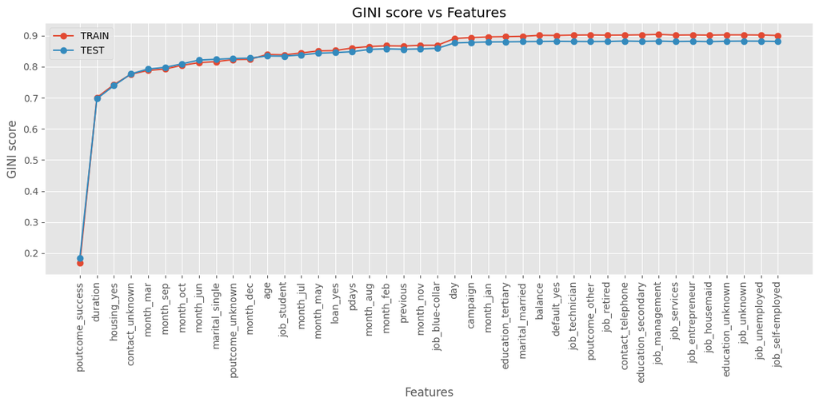

```python
gini_per_feat(model=grid_search2,df_train=X_train_d,train_y=y_train,df_test=X_test_d,test_y=y_test,params=grid_search2.best_params_)
```

Na podstawie wykresu widać wyraźnie, że po dodaniu około 23 pierwszych zmiennych (do zmiennej `day` włącznie), jakość modelu – mierzona współczynnikiem GINI – przestaje istotnie się poprawiać.  
Co więcej, dalsze dodawanie cech nie tylko nie zwiększa skuteczności, ale może prowadzić do zwiększenia złożoności modelu bez korzyści predykcyjnych.

W związku z tym możliwe jest zredukowanie liczby zmiennych do 23, bez istotnej utraty jakości, co może korzystnie wpłynąć na przejrzystość modelu i jego interpretowalność.

## Model 5 - model champion ze zoptymalizowaną liczbą zmiennych

```python
df_istotnosc = pd.DataFrame({'features': X_train_d.columns,
                            'feature_importance': grid_search2.best_estimator_.feature_importances_}).sort_values(
                            'feature_importance', ascending=False).reset_index(drop=True)
```

```python
top_feats = df_istotnosc['features'].head(23).tolist()
```

```python
best_params = grid_search2.best_params_
```

```python
X_train_reduced = X_train_d[top_feats].copy()
X_test_reduced = X_test_d[top_feats].copy()
```

```python
model_final = xgb.XGBClassifier(**best_params)
model_final.fit(X_train_reduced,y_train);
```

```python
summary5 = model_summary(model_final, "Model 5", "model champion ze zoptymalizowaną liczbą zmiennych", X_train_reduced, X_test_reduced , y_train, y_test)
model_results = pd.concat([model_results, summary5], ignore_index=True)
model_results.style.format(lambda x: f"{x:.3f}" if isinstance(x, float) else x) \
        .set_table_styles([
        {'selector': 'td, th', 'props': [('border', '1px solid black')]},
        {'selector': 'tr:nth-child(even)', 'props': [('background-color', 'lightgray')]},
        {'selector': 'tr:nth-child(odd)', 'props': [('background-color', 'white')]},
        {'selector': 'caption', 'props': [('font-weight', 'bold')]},
    ]) \
    .hide(axis="index").set_table_attributes("style='margin:auto; font-size:16px'").set_caption("Podsumowanie modeli")
```

Podsumowanie modeli

| Nazwa modelu | Opis | Liczba zmiennych | Gini TRAIN | Gini TEST |
| --- | --- | --- | --- | --- |
| Model 1 | model na domyślnych hiperparametrach | 16 | 96.024 | 86.911 |
| Model 2 | model ze zoptymalizowanymi hiperparametrami | 16 | 92.149 | 87.338 |
| Model 3 | model na domyślnych parametrach ze zmiennymi dummy | 42 | 95.659 | 87.722 |
| Model 4 | model ze zoptymalizowanymi hiperparametrami ze zmiennymi dummy | 42 | 90.299 | 88.224 |
| Model 5 | model champion ze zoptymalizowaną liczbą zmiennych | 23 | 89.056 | 87.653 |

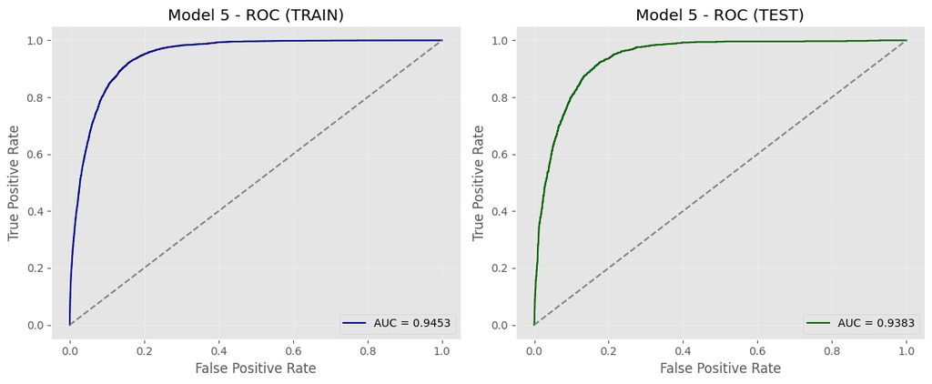

```python
rysuj_roc(model_final, X_train_reduced, y_train, X_test_reduced, y_test, model_name="Model 5")
```

## Ocena predykcji

Wartości GINI oraz ROC AUC potwierdzają, że model zachowuje wysoką jakość predykcji, a jego zdolność do uogólniania jest bardzo dobra.  
Niewielka różnica między wynikami dla zbioru treningowego i testowego świadczy o stabilności i braku przeuczenia.

Widzimy zatem, że Model 5 oferuje niemal taką samą jakość predykcji jak Model 4, a przy tym bazuje na znacznie mniejszej liczbie zmiennych (23 zamiast 42), co czyni go bardziej przejrzystym, efektywnym i łatwiejszym do wdrożenia.  
W praktyce – to bardzo silny kandydat na nowego "championa".

## Wpływ zmiennych

W celu zrozumienia, w jaki sposób poszczególne zmienne wpływają na predykcję modelu, posłużymy się metodą SHAP.

```python
warnings.filterwarnings("ignore")
explainer = shap.TreeExplainer(model_final,X_train_reduced)
shap_values = explainer.shap_values(X_train_reduced)
```

```
100%|===================| 36048/36168 [02:07<00:00]
```

```python
warnings.filterwarnings("ignore")
explainer1 = shap.TreeExplainer(model_final,X_test_reduced)
shap_values1 = explainer.shap_values(X_test_reduced)
```

```
100%|===================| 9040/9043 [00:34<00:00]
```

### Wykres dla TRAIN

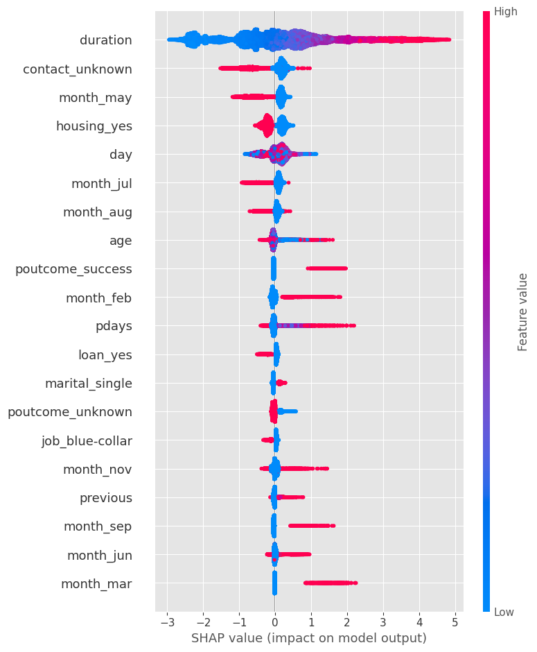

```python
shap.summary_plot(shap_values,X_train_reduced)
```

### Wykres dla TEST

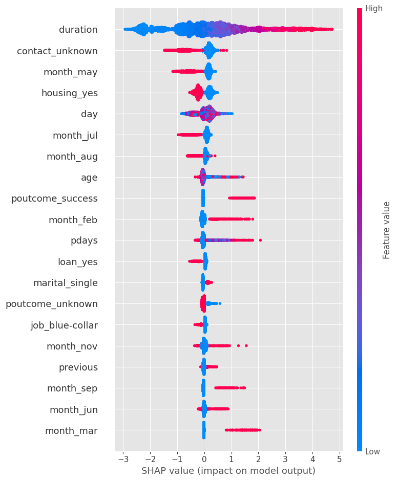

```python
shap.summary_plot(shap_values1,X_test_reduced)
```

## Obserwacje i wnioski

Powyższy wykres przedstawia wpływ poszczególnych zmiennych (cech) na predykcję modelu klasyfikacyjnego, który miał na celu przewidywanie, czy klient zdecyduje się na lokatę terminową.

Każda kropka na wykresie odpowiada jednej obserwacji w zbiorze danych, a jej pozycja na osi X reprezentuje wartość SHAP – czyli wpływ tej konkretnej cechy w tej konkretnej obserwacji na przewidywanie klasy 1 (decyzja pozytywna). Kolor kropki oznacza wartość cechy: czerwony oznacza wartości wysokie, a niebieski niskie.

Wartości dodatnie SHAP oznaczają, że dana cecha zwiększa prawdopodobieństwo klasy 1 (przyjęcie oferty), natomiast wartości ujemne – że zmniejsza.

`duration` (czas trwania ostatniego kontaktu telefonicznego) – to zdecydowanie najważniejsza cecha.  
Długie rozmowy mają przeważnie dodatnie wartości SHAP, co oznacza, że znacznie zwiększają szanse na pozytywną decyzję.  
Krótkie rozmowy zwykle znajdują się po lewej stronie, czyli zmniejszają prawdopodobieństwo sukcesu kampanii.

`contact_unknown` (oznacza brak informacji o sposobie kontaktu) - Wysoka wartość tej cechy znajduje się głównie po lewej stronie, co sugeruje, że w takich przypadkach model przewiduje niższe prawdopodobieństwo sukcesu kampanii.

`month_may` – kontakty w maju obniżają prawdopodobieństwo sukcesu.  
Może to wynikać z faktu, że w tym miesiącu przeprowadzano wiele rozmów z klientami mniej skłonnymi do przyjęcia oferty.

`housing_yes` – posiadanie kredytu hipotecznego jest zazwyczaj związane z niższym prawdopodobieństwem pozytywnej decyzji.

`day` (numer dnia miesiąca, w którym nastąpił ostatni kontakt) - zmienna ma rozproszony wpływ – nie widać jednoznacznego kierunku, ale wartości rozciągają się w obie strony.

`month_jul` i `month_aug` - większość punktów (czerwonych) znajduje się po lewej stronie.  
Kontakt w miesiące wakacyjne wiąże się z niższą skutecznością kampanii.

`age` - Czerwone kropki (czyli starsi klienci) są głównie po prawej stronie.  
Starsze osoby częściej akceptują ofertę lokaty.

`poutcome_success` – jeśli klient w poprzedniej kampanii przyjął ofertę, to taka obserwacja znajduje się po prawej stronie, czyli zwiększa prawdopodobieństwo przyjęcia obecnej oferty .

`month_feb` - duża część punktów widoczna jest po stronie prawej.  
Kontakt w tym miesiącu zwiększa sukces kampanii.

`pdays`(liczba dni od ostatniego kontaktu klienta w poprzedniej kampanii) - spora część (czerwonych) punktów znajduje się po prawej stronie, co sugeruje, że im większy czas od ostatniego kontaktu tym większe prawdopodobieństwo sukcesu.

`loan_yes`- Obserwujemy, że osoby z kredytem są mniej zainteresowane dodatkowymi produktami finansowymi.

`martial_single`- Czerwone kropki są przeważnie po prawej stronie.  
Osoby samotne częściej decydują się na lokatę.

`poutcome_unknown`- obserwacje z nieznanym wynikiem poprzedniej kampanii przeważnie obniżają prawdopodobieństwo sukcesu.  
Jednak w niektórych przypadkach zmienna ta może mieć również dodatni wpływ, co może wynikać z jej współzależności z innymi cechami.

`job_blue-collar`- Czerwone punkty wyraźnie po lewej stronie.  
Praca fizyczna zmniejsza szanse na sukces kampanii.

`month_nov`, `month_sep`, `month_jun`,`month_mar` - Większość punktów widzimy po prawej stronie.  
Sugeruje to, że kontakt w tych miesiącach zwiększa szanse na subskrypcje lokaty.

`previous` (liczba kontaktów wykonanych przed tą kampanią dla danego klienta) - Czerwone kropki (świadczące o większej liczbie) znajdują się głównie po prawej stronie, co sugeruje że kontakt z poprzednimi klientami zwiększa szanse na poztywną decyzję.

Warto również zauważyć, że podobne wnioski nasuwały się podczas *Eksploracyjnej analizy danych* w "Części I".